# Research and Data Analysis - Red Wine Data

We use the file ‘red_wine_data.csv’.  
This dataset is related to red variant of the Portuguese "Vinho Verde" wine.  
Only physicochemical (inputs) and sensory (the output) variables are available (e.g. there is no data about grape types, wine brand, wine selling price, etc.).  
The classes are ordered and not balanced (e.g. there are many more normal wines than excellent or poor ones).

Input variables (based on physicochemical tests):  
1 - fixed acidity  
2 - volatile acidity  
3 - citric acid  
4 - residual sugar  
5 - chlorides  
6 - free sulfur dioxide  
7 - total sulfur dioxide  
8 - density  
9 - pH  
10 - sulphates  
11 - alcohol

Output variable (based on sensory data):  
12 - quality (score between 0 and 10)

My task is to analyse the data and present my findings during the interview.  
I may take a descriptive approach and think about potential ways to present the data, or to apply any statistical technique to the data to answer a research question that I think can be answered with this data.

**Task Specification**: after careful analysis of the dataset and the referenced paper, I have decided to perform the following tasks.

1. Take a descriptive approach to present the data, and
2. apply statitical techniques to answer a research question that I think can be answered with the data: can ensemble trees improve the red wine quality classification relative to SVM, MLP and Linear Regression models?

I believe that answering the research question is important, since the referenced paper enhances the superior predictive power of SVM relative to linear regression and multilayer perceptron (MLP). A natural question to ask is how ensemble tree methods, that have proved important for numerous classification/regression tasks, stand with respect to SVM and for red wine quality classification. Performing our research can help to dilucidate where SVM stands with respect to ensemble trees in this context.

[Reference](https://www.sciencedirect.com/science/article/abs/pii/S0167923609001377): P. Cortez, A. Cerdeira, F. Almeida, T. Matos and J. Reis. Modeling wine preferences by data mining from physicochemical properties. In Decision Support Systems, Elsevier, 47(4):547-553, 2009.

```python
%%capture
# install libraries
!pip install lightgbm ipywidgets matplotlib numpy pandas plotly seaborn scikit-learn shap skorch statsmodels torch xgboost
```

```python
# libraries
import lightgbm as lgb
import matplotlib.pyplot as plt
import numpy as np
import pandas as pd
import seaborn as sns
#
from scipy.stats import pearsonr, spearmanr, t
from sklearn.decomposition import PCA
from sklearn.ensemble import ExtraTreesRegressor, RandomForestRegressor
from sklearn.feature_selection import mutual_info_regression
from sklearn.metrics import make_scorer, mean_absolute_error, mean_squared_error
from sklearn.model_selection import cross_validate, KFold, train_test_split
from sklearn.neural_network import MLPRegressor
from sklearn.preprocessing import StandardScaler
from sklearn.svm import SVR
from sklearn.tree import DecisionTreeRegressor
from statsmodels.stats.outliers_influence import variance_inflation_factor
from xgboost import XGBRegressor
#
import shap
import torch
import warnings
warnings.filterwarnings("ignore")
```

```python
# functions
def calculate_smape(y_true, y_pred):
    return 100 * np.mean(2 * np.abs(y_pred - y_true) / (np.abs(y_pred) + np.abs(y_true)))
def calculate_mape(y_true, y_pred):
    return 100 * np.mean(np.abs((y_true - y_pred) / y_true))
def accuracy_within_tolerance(y_true, y_pred, scaler_y, tolerance):
    y_true_orig_scale = scaler_y.inverse_transform(y_true.reshape(-1, 1)).flatten()
    y_pred_orig_scale = scaler_y.inverse_transform(y_pred.reshape(-1, 1)).flatten()
    within_tolerance = np.sum(np.abs(y_true_orig_scale - y_pred_orig_scale) <= tolerance)
    total_samples = len(y_true)
    accuracy = within_tolerance / total_samples * 100
    return accuracy
# parameters
random_state = 42
np.random.seed(random_state)
torch.manual_seed(random_state)
test_size = 0.2
tolerance = 0.5
num_runs = 20
confidence_level = 0.95
degrees_of_freedom = num_runs - 1
kf = KFold(n_splits=5, shuffle=True, random_state=random_state)
```

## 1. Descriptive Analysis

```python
df=pd.read_csv(r'red_wine_data/red_wine_data.csv')
df
```

|  | fixedAcidity | volatileAcidity | citricAcid | residualSugar | chlorides | freeSulfurDioxide | totalSulfurDioxide | density | pH | sulphates | alcohol | quality |
| --- | --- | --- | --- | --- | --- | --- | --- | --- | --- | --- | --- | --- |
| 0 | 7.4 | 0.700 | 0.00 | 1.9 | 0.076 | 11.0 | 34.0 | 0.99780 | 3.51 | 0.56 | 9.4 | 5 |
| 1 | 7.8 | 0.880 | 0.00 | 2.6 | 0.098 | 25.0 | 67.0 | 0.99680 | 3.20 | 0.68 | 9.8 | 5 |
| 2 | 7.8 | 0.760 | 0.04 | 2.3 | 0.092 | 15.0 | 54.0 | 0.99700 | 3.26 | 0.65 | 9.8 | 5 |
| 3 | 11.2 | 0.280 | 0.56 | 1.9 | 0.075 | 17.0 | 60.0 | 0.99800 | 3.16 | 0.58 | 9.8 | 6 |
| 4 | 7.4 | 0.700 | 0.00 | 1.9 | 0.076 | 11.0 | 34.0 | 0.99780 | 3.51 | 0.56 | 9.4 | 5 |
| ... | ... | ... | ... | ... | ... | ... | ... | ... | ... | ... | ... | ... |
| 1594 | 6.2 | 0.600 | 0.08 | 2.0 | 0.090 | 32.0 | 44.0 | 0.99490 | 3.45 | 0.58 | 10.5 | 5 |
| 1595 | 5.9 | 0.550 | 0.10 | 2.2 | 0.062 | 39.0 | 51.0 | 0.99512 | 3.52 | 0.76 | 11.2 | 6 |
| 1596 | 6.3 | 0.510 | 0.13 | 2.3 | 0.076 | 29.0 | 40.0 | 0.99574 | 3.42 | 0.75 | 11.0 | 6 |
| 1597 | 5.9 | 0.645 | 0.12 | 2.0 | 0.075 | 32.0 | 44.0 | 0.99547 | 3.57 | 0.71 | 10.2 | 5 |
| 1598 | 6.0 | 0.310 | 0.47 | 3.6 | 0.067 | 18.0 | 42.0 | 0.99549 | 3.39 | 0.66 | 11.0 | 6 |

1599 rows × 12 columns

```python
# define variable types
numeric = [
    'fixedAcidity',
    'volatileAcidity',
    'citricAcid',
    'residualSugar',
    'chlorides',
    'freeSulfurDioxide',
    'totalSulfurDioxide',
    'density',
    'pH',
    'sulphates',
    'alcohol',
           ]
categorical = [
    'quality'
]
```

```python
# check nans and infs
for col in numeric:
    print(f"{col} nan values: {np.isnan(df[col]).sum()}")
    print(f"{col} inf values: {np.isinf(df[col]).sum()}")
for col in categorical:
    print(f"{col} nan values: {np.isnan(df[col]).sum()}")
    print(f"{col} inf values: {np.isinf(df[col]).sum()}")
```

```
fixedAcidity nan values: 0
fixedAcidity inf values: 0
volatileAcidity nan values: 0
volatileAcidity inf values: 0
citricAcid nan values: 0
citricAcid inf values: 0
residualSugar nan values: 0
residualSugar inf values: 0
chlorides nan values: 0
chlorides inf values: 0
freeSulfurDioxide nan values: 0
freeSulfurDioxide inf values: 0
totalSulfurDioxide nan values: 0
totalSulfurDioxide inf values: 0
density nan values: 0
density inf values: 0
pH nan values: 0
pH inf values: 0
sulphates nan values: 0
sulphates inf values: 0
alcohol nan values: 0
alcohol inf values: 0
quality nan values: 0
quality inf values: 0
```

```python
# summary statistics
summary_statistics = df.describe(percentiles=[]).apply(lambda x: round(x, 4))
# Print summary statistics table
summary_statistics
```

|  | fixedAcidity | volatileAcidity | citricAcid | residualSugar | chlorides | freeSulfurDioxide | totalSulfurDioxide | density | pH | sulphates | alcohol | quality |
| --- | --- | --- | --- | --- | --- | --- | --- | --- | --- | --- | --- | --- |
| count | 1599.0000 | 1599.0000 | 1599.0000 | 1599.0000 | 1599.0000 | 1599.0000 | 1599.0000 | 1599.0000 | 1599.0000 | 1599.0000 | 1599.0000 | 1599.0000 |
| mean | 8.3196 | 0.5278 | 0.2710 | 2.5388 | 0.0875 | 15.8749 | 46.4678 | 0.9967 | 3.3111 | 0.6581 | 10.4230 | 5.6360 |
| std | 1.7411 | 0.1791 | 0.1948 | 1.4099 | 0.0471 | 10.4602 | 32.8953 | 0.0019 | 0.1544 | 0.1695 | 1.0657 | 0.8076 |
| min | 4.6000 | 0.1200 | 0.0000 | 0.9000 | 0.0120 | 1.0000 | 6.0000 | 0.9901 | 2.7400 | 0.3300 | 8.4000 | 3.0000 |
| 50% | 7.9000 | 0.5200 | 0.2600 | 2.2000 | 0.0790 | 14.0000 | 38.0000 | 0.9968 | 3.3100 | 0.6200 | 10.2000 | 6.0000 |
| max | 15.9000 | 1.5800 | 1.0000 | 15.5000 | 0.6110 | 72.0000 | 289.0000 | 1.0037 | 4.0100 | 2.0000 | 14.9000 | 8.0000 |

We can see the different magnitude of some of the variables. Something that we can deal with by standardizing each feature later on in our machine learning exercise.

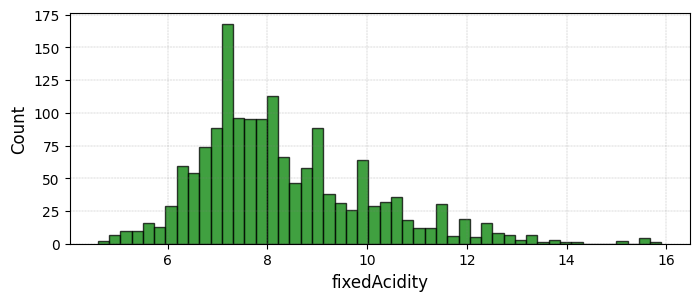

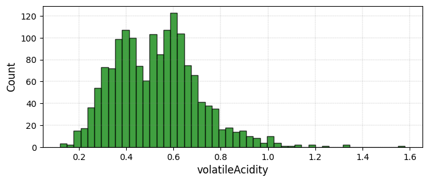

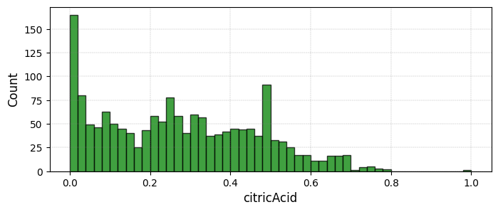

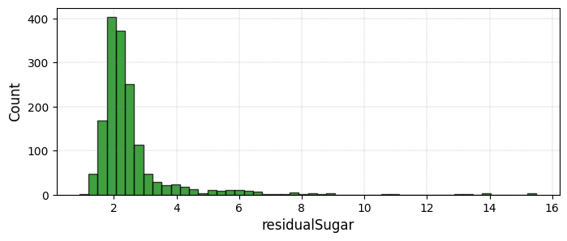

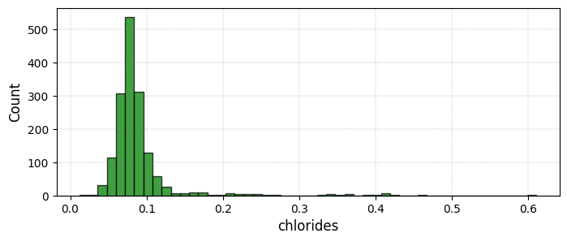

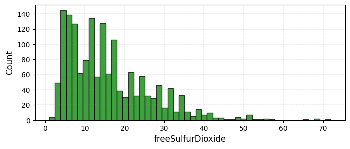

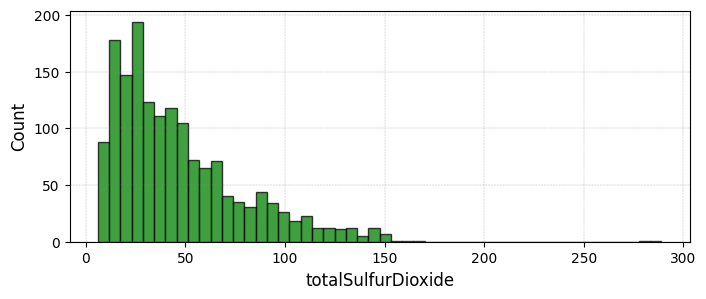

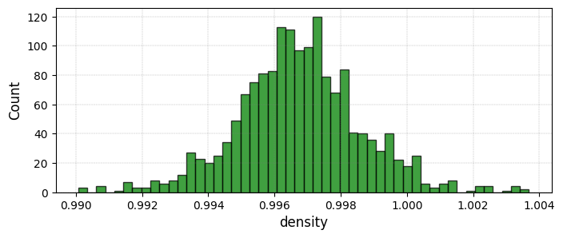

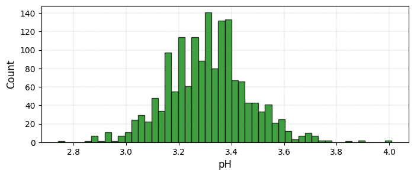

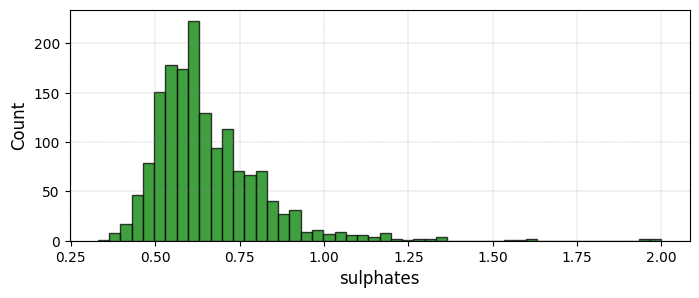

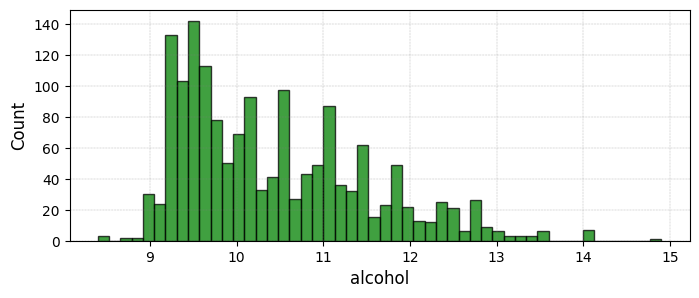

```python
# plot continuous
for var in numeric:
    plt.figure(figsize=(8,3))
    plt.hist(df[var],50,facecolor='g', alpha=0.75, histtype='bar', ec='black')
    plt.ylabel('Count',fontsize=12)
    plt.xlabel(var,fontsize=12)
    plt.grid(True, color = "grey", linewidth = "0.2", linestyle = "-.")
    plt.show()
```

We can see that there are outliers in some of the variables.  
While we don't do anything about it here, we could proceed to treat outliers in the following form:  
1-Winsorizing or Clipping setting a threshold such that outside this threshold values are replaced with the threshold.  
2-Dropping Outliers using statistical methods.  
3-Transforming the data (logarithmic, square root, Box-Cox, ...) to have a more compressed distribution.

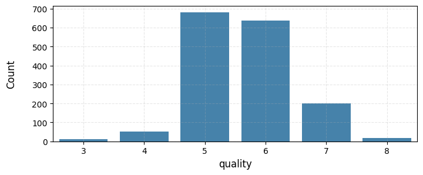

```python
# plot categorical
for var in categorical:
    plt.figure(figsize=(8,3))
    count = df[var].value_counts()
    count.index=count.index.astype(int)
    sns.barplot(count[0:20],alpha=0.9)
    plt.ylabel('Count\n',fontsize=12)
    plt.xlabel(var,fontsize=12)
    plt.grid(True, alpha=0.3, linestyle='--')
    plt.show()
```

```python
df[var].value_counts().sort_index()
```

```
quality
3     10
4     53
5    681
6    638
7    199
8     18
Name: count, dtype: int64
```

The above graph shows that the classes (quality) are imbalanced.  
There are many techniques to deal with imbalanced data:  
1- Resampling: Undersampling (remove samples from the over-represented classes) or Oversampling (generate new samples from the under-represented class).  
2- Weight classes: adjust class weights in the ML algorithm to address the class imbalance when doing a classification task.  
3- Ensemble methods: bagging and boosting methods can improve the model's performance of the minority class.  
4- Use appropriate evaluation metrics: when doing a classification task we may want to use precision, recall and F1-score. These metrics provide a more comprehensive view of model performance on imbalanced datasets for classification tasks.

```python
# Multicollinearity test
# Variance Inflation Factor (VIF)
# VIF measures how much the variance of an estimated regression coefficient increases if predictors are correlated.
# A high VIF indicates that a predictor variable is highly collinear with the other predictor variables.
vif_data = df.copy()
vif = pd.DataFrame()
vif["Variable"] = vif_data.columns
vif["VIF"] = [variance_inflation_factor(vif_data.values, i) for i in range(vif_data.shape[1])]

# Print the VIF values
print(vif)
```

```
              Variable          VIF
0         fixedAcidity    74.455312
1      volatileAcidity    17.960867
2           citricAcid     9.192549
3        residualSugar     4.664003
4            chlorides     6.641291
5    freeSulfurDioxide     6.460603
6   totalSulfurDioxide     6.605274
7              density  1528.154302
8                   pH  1078.171089
9            sulphates    22.462103
10             alcohol   147.616345
11             quality    77.728259
```

If multicollinearity is detected, it can impact the stability and interpretability of classification/regression models.  
The commonly used rule of thumb is that a Variance Inflation Factor (VIF) value above 10 indicates a problematic level of multicollinearity.  
The Multicollinearity test shows that some variables in the dataset are highly correlated, leading to potential issues in a classification analysis, such as overfitting, or model instability.  
Across different machine learning models, linear regression is the model that can potentially be most affected by multicollinearity. Neural Networks, do to their non-linearity nature, are less affected. SVMs are generally robust to multicollinearity, thanks to their ability to focus on the most informative data points (support vectors). Finally, ensemble trees are generally robust to multicollinearity due to their non-linear hierarchical splitting, bagging and their random selection of features.

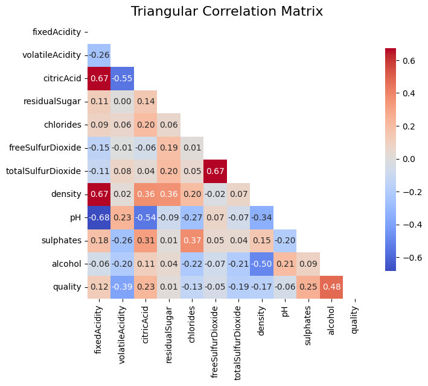

```python
# Assuming df is your DataFrame
correlation_matrix = np.corrcoef(df, rowvar=False)

# Create a mask to hide the upper triangular part and the diagonal
mask = np.triu(np.ones_like(correlation_matrix), k=1)
correlation_matrix[np.eye(correlation_matrix.shape[0], dtype=bool)] = np.nan

# Set up the matplotlib figure
fig, ax = plt.subplots(figsize=(8, 6))

# Create a seaborn heatmap with the masked upper triangle and no diagonal
heatmap = sns.heatmap(correlation_matrix, mask=mask, annot=True, cmap="coolwarm", fmt=".2f", cbar_kws={"shrink": 0.8})

# Customize the plot (optional)
plt.title('Triangular Correlation Matrix', fontsize=16)

# Use original column names as tick labels and rotate them
plt.xticks(np.arange(correlation_matrix.shape[0]) + 0.5, labels=df.columns, rotation=90)
plt.yticks(np.arange(correlation_matrix.shape[0]) + 0.5, labels=df.columns, rotation=0)  # You can adjust the rotation angle here

# Adjust the aspect ratio to make the squares square
heatmap.set_aspect('equal')

plt.show()
```

The pairwise correlation analysis confirms the findings of the multicollinearity test.  
Potential approaches to address or mitigate multicollinearity:  
1- Remove highly correlated variables: of the highly correlated pairs of variables, keep just one.  
2- Use Principal Component Analysis (PCA) to transform the set of variables into a set of linearly uncorrelated variables (principal components).  
3- Exclude variables with the highest VIF values.  
4- Use L2 regularization (Ridge Regression): Ridge regression penalizes the sum of squared coefficients, distributing the impact of correlated variables more evenly, preventing one variable from dominating the others.

Below, we simply illustrate how we could perform PCA to avoid multicollinearity and reduce the number of features for the inputs of our machine learning application.

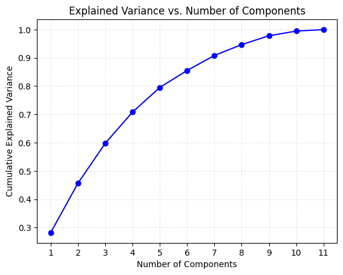

```python
# Standardize the features
scaler = StandardScaler()
df_standardized = scaler.fit_transform(df.loc[:, ~df.columns.isin(categorical)])

# Fit PCA
pca = PCA()
pca.fit(df_standardized)

# Calculate the cumulative explained variance
cumulative_variance = np.cumsum(pca.explained_variance_ratio_)
# Plot the explained variance and look for an elbow point
plt.plot(range(1, len(cumulative_variance) + 1), cumulative_variance, marker='o', linestyle='-', color='b')
plt.title('Explained Variance vs. Number of Components')
plt.xlabel('Number of Components')
plt.ylabel('Cumulative Explained Variance')
plt.grid(True,alpha=0.3,linestyle='--')
# Set xticks for each component
plt.xticks(range(1, len(cumulative_variance) + 1))
plt.show()
```

We can select the number of components to retain a variance of 90% of the total variance of the features.  
With this threshold we balance information retention and model complexity.

```python
# Perform PCA with n_components=7
n_components = 7
pca = PCA(n_components=n_components)
df_pca = pca.fit_transform(df_standardized)
```

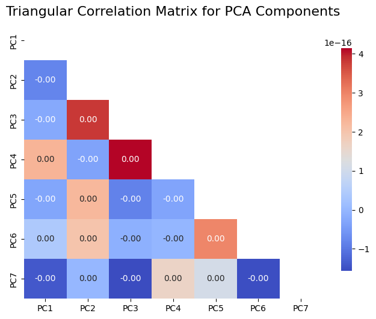

```python
# Calculate the correlation matrix for df_pca
correlation_matrix = np.corrcoef(df_pca, rowvar=False)
# Create a mask to hide the upper triangular part and the diagonal
mask = np.triu(np.ones_like(correlation_matrix), k=1)
correlation_matrix[np.eye(correlation_matrix.shape[0], dtype=bool)] = np.nan
# Set up the matplotlib figure
fig, ax = plt.subplots(figsize=(8, 6))
# Create a seaborn heatmap with the masked upper triangle and no diagonal
sns.heatmap(correlation_matrix, mask=mask, annot=True, cmap="coolwarm", fmt=".2f", cbar_kws={"shrink": 0.8})
# Customize the plot (optional)
plt.title('Triangular Correlation Matrix for PCA Components', fontsize=16)
# Center the ticks in the middle of the squares
tick_positions = np.arange(0.5, correlation_matrix.shape[0] + 0.5)
plt.xticks(tick_positions, labels=[f'PC{i+1}' for i in range(correlation_matrix.shape[0])])
plt.yticks(tick_positions, labels=[f'PC{i+1}' for i in range(correlation_matrix.shape[0])])
# Show the plot
plt.show()
```

We can see that the principal components are orthogonal (linearly uncorrelated) to each other.

Now we calculate Pearson correlation, Spearman correlation and Mutual Information of the features and the target (quality).

a. Pearson Correlation measures the linear relationship between two variables.  
b. Spearman Correlation (also called rank information coefficient) measures the monotonic relationship between two variables.  
c. Mutual Information is a covariance-free measure of dependence between two variables. Using conditional entropy, it measures the reduction in uncertainty about the target due to the knowledge of the predictor.

```python
# Calculate Pearson correlation
pearson_correlations = df.apply(lambda x: pearsonr(x, df[categorical[0]]).correlation)
# Calculate Spearman correlation
spearman_correlations = df.apply(lambda x: spearmanr(x, df[categorical[0]]).correlation)
# Calculate Mutual Information
mutual_info = df.apply(lambda x: mutual_info_regression(x.values.reshape(-1, 1), df[categorical[0]]))
columns_without_target = [col for col in df.columns if col != categorical[0]]
# Create a DataFrame to display the results
correlation_results = pd.DataFrame({
    'Feature': columns_without_target,
    'Pearson_Correlation': pearson_correlations.drop(index=['quality']),
    'Spearman_Correlation': spearman_correlations.drop(index=['quality']),
    'Mutual_Information': mutual_info.drop(columns=['quality']).T.squeeze()
}).reset_index(drop=True)
correlation_results.sort_values(by=["Mutual_Information"], ascending=False).reset_index(drop=True)
```

|  | Feature | Pearson_Correlation | Spearman_Correlation | Mutual_Information |
| --- | --- | --- | --- | --- |
| 0 | alcohol | 0.476166 | 0.478532 | 0.153851 |
| 1 | sulphates | 0.251397 | 0.377060 | 0.114384 |
| 2 | volatileAcidity | -0.390558 | -0.380647 | 0.103030 |
| 3 | density | -0.174919 | -0.177074 | 0.096649 |
| 4 | totalSulfurDioxide | -0.185100 | -0.196735 | 0.090495 |
| 5 | chlorides | -0.128907 | -0.189922 | 0.059152 |
| 6 | fixedAcidity | 0.124052 | 0.114084 | 0.057060 |
| 7 | citricAcid | 0.226373 | 0.213481 | 0.044180 |
| 8 | residualSugar | 0.013732 | 0.032048 | 0.028478 |
| 9 | pH | -0.057731 | -0.043672 | 0.013486 |
| 10 | freeSulfurDioxide | -0.050656 | -0.056901 | 0.012240 |

We see that `alcohol` has the highest Mutual Information with both a high positive Pearson and Spearman correlation. The correlation analysis suggest that alcohol is the most important feature to predict red wine quality, and that there is a positive linear and monotonic relationship between alcohol and red wine quality.  
Similarly, `sulphates` has a relatively high Mutual Information with both a high positive Pearson and Spearman correlation.  
Finally, other features seem to be important to predict red wine quality, but they have a negative linear and monotonic relationship with quality. These are `volatileAcidity`, `density` and `totalSulfurDioxide`.

# 2. Machine Learning Methods

In this section we study the performance of different Machine Learning techniques to predict red wine quality from physicochemical inputs.

1. Linear Regression model: in practice we use a Multilayer Perceptron model with 0 hidden layers.
2. Multilayer Perceptron model (MLP): the most common neural network type with connected feedforward links. We use 1 hidden layer with 100 nodes.
3. Support Vector Machine (SVM): finds a hyperplane in the feature space that best separates the data points of different classes. We use a Gaussian kernel function to transform the input data into a higher-dimensional space, which allows non-linearities in the decision boundary of the original feature space. The regularization parameter (C) controls the trade-off between a smooth decision boundary and classifying the training points correctly. A higher C enforces a stricter decision boundary. We set C = 3.
4. Decision Tree: tree-like model that splits the dataset into subsets, leading to a tree-like structure of decision nodes and leaf nodes.
5. Random Forest: constructs a multitude of decision trees using bagging (training models in parallel with subsets of data) and random feature selection, choosing the best split.
6. Extra Trees: similar to Random Forest, choosing random splits. Instead of selecting the best split among the randomly chosen features, Extra Trees introduce more randomness by selecting a random split for each feature.
7. XGBoost (Extreme Gradient Boosting): optimized stochastic gradient boosting with tree-pruning and regularization. Grows trees level-wise (fully balanced).
8. Light GBM (Light Gradient Boosting Machine): histogram-based approach, splitting the nodes with higher loss function. Grows trees in a leaf-wise fashion.

We use `scikit-learn` library to build the above models using default parameters.  
Similar to Cortez (2009), we adopt a regression approach in order to preserve the order of preferences/quality of red wine.  
Before fitting the models, we standardize the data to a zero mean and one standard deviation.  
For evaluation of the above models we use 5-fold cross-validation and adopt 20 runs.

```python
# Split the dataset into training and testing sets
X = df.loc[:, ~df.columns.isin(categorical)]
y = df[categorical[0]]
scaler_X = StandardScaler()
X = scaler_X.fit_transform(X)
scaler_y = StandardScaler()
y = scaler_y.fit_transform(y.values.reshape(-1, 1)).flatten()
X_train, X_test, y_train, y_test = train_test_split(X, y, # df_pca
                                                    test_size=test_size,
                                                    random_state=random_state)
```

Evaluation Metrics:

MAD: Mean Absolute Deviation  
MSE: Mean Squared Error  
SMAPE: Symmetric Mean Absolute Percentage Error  
MAPE: Mean Absolute Percentage Error  
Accuracy: given the regression prediction, we construct the accuracy of the class prediction for a tolerance of 0.5.

```python
# Create MLP model with zero hidden layers (equivalent to Linear Regression)
lr_model = MLPRegressor(
    hidden_layer_sizes=(),  # Empty tuple means zero hidden layers
    max_iter=300,
    random_state=42
)
mads = []
smapes = []
mses = []
mapes = []
accuracies = []
# Update the scorers dictionary
scorers = {
    'mad': make_scorer(mean_absolute_error),
    'mse': make_scorer(mean_squared_error),
    'mape': make_scorer(calculate_mape),
    'smape': make_scorer(calculate_smape),
    'accuracy_within_tolerance': make_scorer(accuracy_within_tolerance, scaler_y=scaler_y, tolerance=tolerance)
}
for run in range(num_runs):
    # Perform 5-fold cross-validation and get the scores for each metric
    cv_results = cross_validate(lr_model, X, y, cv=kf, scoring=scorers)
    mads.append(cv_results['test_mad'])
    mses.append(cv_results['test_mse'])
    mapes.append(cv_results['test_mape'])
    smapes.append(cv_results['test_smape'])
    accuracies.append(cv_results['test_accuracy_within_tolerance'])
average_mad = np.mean(mads)
average_mse = np.mean(mses)
average_mape = np.mean(mapes)
average_smape = np.mean(smapes)
average_accuracy = np.mean(accuracies)
confidence_interval_mad = t.interval(confidence_level, degrees_of_freedom, loc=average_mad, scale=np.std(mads))
confidence_interval_mse = t.interval(confidence_level, degrees_of_freedom, loc=average_mse, scale=np.std(mses))
confidence_interval_mape = t.interval(confidence_level, degrees_of_freedom, loc=average_mape, scale=np.std(mapes))
confidence_interval_smape = t.interval(confidence_level, degrees_of_freedom, loc=average_smape, scale=np.std(smapes))
confidence_interval_accuracy = t.interval(confidence_level, degrees_of_freedom, loc=average_accuracy, scale=np.std(accuracies))
lr = pd.DataFrame({'average': [average_mad, average_mse, average_mape, average_smape, average_accuracy]
                    , 'upper': [confidence_interval_mad[1], confidence_interval_mse[1], confidence_interval_mape[1], confidence_interval_smape[1], confidence_interval_accuracy[1]]
                    , 'lower': [confidence_interval_mad[0], confidence_interval_mse[0], confidence_interval_mape[0], confidence_interval_smape[0], confidence_interval_accuracy[0]]})
lr['Model'] = "Linear Regression"
lr['Metric'] = scorers.keys()
```

```python
# Create MLP model
mlp_model = MLPRegressor(
    hidden_layer_sizes=(100,),
    max_iter=300,
    random_state=42
)
mads = []
smapes = []
mses = []
mapes = []
accuracies = []
# Update the scorers dictionary
scorers = {
    'mad': make_scorer(mean_absolute_error),
    'mse': make_scorer(mean_squared_error),
    'mape': make_scorer(calculate_mape),
    'smape': make_scorer(calculate_smape),
    'accuracy_within_tolerance': make_scorer(accuracy_within_tolerance, scaler_y=scaler_y, tolerance=tolerance)
}
for run in range(num_runs):
    # Perform 5-fold cross-validation and get the scores for each metric
    cv_results = cross_validate(mlp_model, X, y, cv=kf, scoring=scorers)
    mads.append(cv_results['test_mad'])
    mses.append(cv_results['test_mse'])
    mapes.append(cv_results['test_mape'])
    smapes.append(cv_results['test_smape'])
    accuracies.append(cv_results['test_accuracy_within_tolerance'])
average_mad = np.mean(mads)
average_mse = np.mean(mses)
average_mape = np.mean(mapes)
average_smape = np.mean(smapes)
average_accuracy = np.mean(accuracies)
confidence_interval_mad = t.interval(confidence_level, degrees_of_freedom, loc=average_mad, scale=np.std(mads))
confidence_interval_mse = t.interval(confidence_level, degrees_of_freedom, loc=average_mse, scale=np.std(mses))
confidence_interval_mape = t.interval(confidence_level, degrees_of_freedom, loc=average_mape, scale=np.std(mapes))
confidence_interval_smape = t.interval(confidence_level, degrees_of_freedom, loc=average_smape, scale=np.std(smapes))
confidence_interval_accuracy = t.interval(confidence_level, degrees_of_freedom, loc=average_accuracy, scale=np.std(accuracies))
mlp = pd.DataFrame({'average': [average_mad, average_mse, average_mape, average_smape, average_accuracy]
                    , 'upper': [confidence_interval_mad[1], confidence_interval_mse[1], confidence_interval_mape[1], confidence_interval_smape[1], confidence_interval_accuracy[1]]
                    , 'lower': [confidence_interval_mad[0], confidence_interval_mse[0], confidence_interval_mape[0], confidence_interval_smape[0], confidence_interval_accuracy[0]]})
mlp['Model'] = "MLP"
mlp['Metric'] = scorers.keys()
```

```python
# Create the SVM model
svm_model = SVR(kernel='rbf', C=3)
mads = []
smapes = []
mses = []
mapes = []
accuracies = []
# Update the scorers dictionary
scorers = {
    'mad': make_scorer(mean_absolute_error),
    'mse': make_scorer(mean_squared_error),
    'mape': make_scorer(calculate_mape),
    'smape': make_scorer(calculate_smape),
    'accuracy_within_tolerance': make_scorer(accuracy_within_tolerance, scaler_y=scaler_y, tolerance=tolerance)
}
for run in range(num_runs):
    # Perform 5-fold cross-validation and get the scores for each metric
    cv_results = cross_validate(svm_model, X, y, cv=kf, scoring=scorers)
    mads.append(cv_results['test_mad'])
    mses.append(cv_results['test_mse'])
    mapes.append(cv_results['test_mape'])
    smapes.append(cv_results['test_smape'])
    accuracies.append(cv_results['test_accuracy_within_tolerance'])
average_mad = np.mean(mads)
average_mse = np.mean(mses)
average_mape = np.mean(mapes)
average_smape = np.mean(smapes)
average_accuracy = np.mean(accuracies)
confidence_interval_mad = t.interval(confidence_level, degrees_of_freedom, loc=average_mad, scale=np.std(mads))
confidence_interval_mse = t.interval(confidence_level, degrees_of_freedom, loc=average_mse, scale=np.std(mses))
confidence_interval_mape = t.interval(confidence_level, degrees_of_freedom, loc=average_mape, scale=np.std(mapes))
confidence_interval_smape = t.interval(confidence_level, degrees_of_freedom, loc=average_smape, scale=np.std(smapes))
confidence_interval_accuracy = t.interval(confidence_level, degrees_of_freedom, loc=average_accuracy, scale=np.std(accuracies))
svm = pd.DataFrame({'average': [average_mad, average_mse, average_mape, average_smape, average_accuracy]
                    , 'upper': [confidence_interval_mad[1], confidence_interval_mse[1], confidence_interval_mape[1], confidence_interval_smape[1], confidence_interval_accuracy[1]]
                    , 'lower': [confidence_interval_mad[0], confidence_interval_mse[0], confidence_interval_mape[0], confidence_interval_smape[0], confidence_interval_accuracy[0]]})
svm['Model'] = "SVM"
svm['Metric'] = scorers.keys()
```

```python
# Decision Tree model
dt_model = DecisionTreeRegressor(random_state=random_state)
mads = []
smapes = []
mses = []
mapes = []
accuracies = []
# Update the scorers dictionary
scorers = {
    'mad': make_scorer(mean_absolute_error),
    'mse': make_scorer(mean_squared_error),
    'mape': make_scorer(calculate_mape),
    'smape': make_scorer(calculate_smape),
    'accuracy_within_tolerance': make_scorer(accuracy_within_tolerance, scaler_y=scaler_y, tolerance=tolerance)
}
for run in range(num_runs):
    # Perform 5-fold cross-validation and get the scores for each metric
    cv_results = cross_validate(dt_model, X, y, cv=kf, scoring=scorers)
    mads.append(cv_results['test_mad'])
    mses.append(cv_results['test_mse'])
    mapes.append(cv_results['test_mape'])
    smapes.append(cv_results['test_smape'])
    accuracies.append(cv_results['test_accuracy_within_tolerance'])
average_mad = np.mean(mads)
average_mse = np.mean(mses)
average_mape = np.mean(mapes)
average_smape = np.mean(smapes)
average_accuracy = np.mean(accuracies)
confidence_interval_mad = t.interval(confidence_level, degrees_of_freedom, loc=average_mad, scale=np.std(mads))
confidence_interval_mse = t.interval(confidence_level, degrees_of_freedom, loc=average_mse, scale=np.std(mses))
confidence_interval_mape = t.interval(confidence_level, degrees_of_freedom, loc=average_mape, scale=np.std(mapes))
confidence_interval_smape = t.interval(confidence_level, degrees_of_freedom, loc=average_smape, scale=np.std(smapes))
confidence_interval_accuracy = t.interval(confidence_level, degrees_of_freedom, loc=average_accuracy, scale=np.std(accuracies))
dt = pd.DataFrame({'average': [average_mad, average_mse, average_mape, average_smape, average_accuracy]
                    , 'upper': [confidence_interval_mad[1], confidence_interval_mse[1], confidence_interval_mape[1], confidence_interval_smape[1], confidence_interval_accuracy[1]]
                    , 'lower': [confidence_interval_mad[0], confidence_interval_mse[0], confidence_interval_mape[0], confidence_interval_smape[0], confidence_interval_accuracy[0]]})
dt['Model'] = "Decision Tree"
dt['Metric'] = scorers.keys()
```

```python
# Random Forest model
rf_model = RandomForestRegressor(random_state=random_state)
mads = []
smapes = []
mses = []
mapes = []
accuracies = []
# Update the scorers dictionary
scorers = {
    'mad': make_scorer(mean_absolute_error),
    'mse': make_scorer(mean_squared_error),
    'mape': make_scorer(calculate_mape),
    'smape': make_scorer(calculate_smape),
    'accuracy_within_tolerance': make_scorer(accuracy_within_tolerance, scaler_y=scaler_y, tolerance=tolerance)
}
for run in range(num_runs):
    # Perform 5-fold cross-validation and get the scores for each metric
    cv_results = cross_validate(rf_model, X, y, cv=kf, scoring=scorers)
    mads.append(cv_results['test_mad'])
    mses.append(cv_results['test_mse'])
    mapes.append(cv_results['test_mape'])
    smapes.append(cv_results['test_smape'])
    accuracies.append(cv_results['test_accuracy_within_tolerance'])

average_mad = np.mean(mads)
average_mse = np.mean(mses)
average_mape = np.mean(mapes)
average_smape = np.mean(smapes)
average_accuracy = np.mean(accuracies)
confidence_interval_mad = t.interval(confidence_level, degrees_of_freedom, loc=average_mad, scale=np.std(mads))
confidence_interval_mse = t.interval(confidence_level, degrees_of_freedom, loc=average_mse, scale=np.std(mses))
confidence_interval_mape = t.interval(confidence_level, degrees_of_freedom, loc=average_mape, scale=np.std(mapes))
confidence_interval_smape = t.interval(confidence_level, degrees_of_freedom, loc=average_smape, scale=np.std(smapes))
confidence_interval_accuracy = t.interval(confidence_level, degrees_of_freedom, loc=average_accuracy, scale=np.std(accuracies))
rf = pd.DataFrame({'average': [average_mad, average_mse, average_mape, average_smape, average_accuracy]
                    , 'upper': [confidence_interval_mad[1], confidence_interval_mse[1], confidence_interval_mape[1], confidence_interval_smape[1], confidence_interval_accuracy[1]]
                    , 'lower': [confidence_interval_mad[0], confidence_interval_mse[0], confidence_interval_mape[0], confidence_interval_smape[0], confidence_interval_accuracy[0]]})
rf['Model'] = "Random Forest"
rf['Metric'] = scorers.keys()
```

```python
# Extra Trees model
extra_trees_model = ExtraTreesRegressor(random_state=random_state)
mads = []
smapes = []
mses = []
mapes = []
accuracies = []
# Update the scorers dictionary
scorers = {
    'mad': make_scorer(mean_absolute_error),
    'mse': make_scorer(mean_squared_error),
    'mape': make_scorer(calculate_mape),
    'smape': make_scorer(calculate_smape),
    'accuracy_within_tolerance': make_scorer(accuracy_within_tolerance, scaler_y=scaler_y, tolerance=tolerance)
}
for run in range(num_runs):
    # Perform 5-fold cross-validation and get the scores for each metric
    cv_results = cross_validate(extra_trees_model, X, y, cv=kf, scoring=scorers)
    mads.append(cv_results['test_mad'])
    mses.append(cv_results['test_mse'])
    mapes.append(cv_results['test_mape'])
    smapes.append(cv_results['test_smape'])
    accuracies.append(cv_results['test_accuracy_within_tolerance'])
average_mad = np.mean(mads)
average_mse = np.mean(mses)
average_mape = np.mean(mapes)
average_smape = np.mean(smapes)
average_accuracy = np.mean(accuracies)
confidence_interval_mad = t.interval(confidence_level, degrees_of_freedom, loc=average_mad, scale=np.std(mads))
confidence_interval_mse = t.interval(confidence_level, degrees_of_freedom, loc=average_mse, scale=np.std(mses))
confidence_interval_mape = t.interval(confidence_level, degrees_of_freedom, loc=average_mape, scale=np.std(mapes))
confidence_interval_smape = t.interval(confidence_level, degrees_of_freedom, loc=average_smape, scale=np.std(smapes))
confidence_interval_accuracy = t.interval(confidence_level, degrees_of_freedom, loc=average_accuracy, scale=np.std(accuracies))
et = pd.DataFrame({'average': [average_mad, average_mse, average_mape, average_smape, average_accuracy]
                    , 'upper': [confidence_interval_mad[1], confidence_interval_mse[1], confidence_interval_mape[1], confidence_interval_smape[1], confidence_interval_accuracy[1]]
                    , 'lower': [confidence_interval_mad[0], confidence_interval_mse[0], confidence_interval_mape[0], confidence_interval_smape[0], confidence_interval_accuracy[0]]})
et['Model'] = "Extra Trees"
et['Metric'] = scorers.keys()
```

```python
# xgb
xgb_model = XGBRegressor(
    seed=random_state
)
mads = []
smapes = []
mses = []
mapes = []
accuracies = []
# Update the scorers dictionary
scorers = {
    'mad': make_scorer(mean_absolute_error),
    'mse': make_scorer(mean_squared_error),
    'mape': make_scorer(calculate_mape),
    'smape': make_scorer(calculate_smape),
    'accuracy_within_tolerance': make_scorer(accuracy_within_tolerance, scaler_y=scaler_y, tolerance=tolerance)
}
for run in range(num_runs):
    # Perform 5-fold cross-validation and get the scores for each metric
    cv_results = cross_validate(xgb_model, X, y, cv=kf, scoring=scorers)
    mads.append(cv_results['test_mad'])
    mses.append(cv_results['test_mse'])
    mapes.append(cv_results['test_mape'])
    smapes.append(cv_results['test_smape'])
    accuracies.append(cv_results['test_accuracy_within_tolerance'])
average_mad = np.mean(mads)
average_mse = np.mean(mses)
average_mape = np.mean(mapes)
average_smape = np.mean(smapes)
average_accuracy = np.mean(accuracies)
confidence_interval_mad = t.interval(confidence_level, degrees_of_freedom, loc=average_mad, scale=np.std(mads))
confidence_interval_mse = t.interval(confidence_level, degrees_of_freedom, loc=average_mse, scale=np.std(mses))
confidence_interval_mape = t.interval(confidence_level, degrees_of_freedom, loc=average_mape, scale=np.std(mapes))
confidence_interval_smape = t.interval(confidence_level, degrees_of_freedom, loc=average_smape, scale=np.std(smapes))
confidence_interval_accuracy = t.interval(confidence_level, degrees_of_freedom, loc=average_accuracy, scale=np.std(accuracies))
xgbm = pd.DataFrame({'average': [average_mad, average_mse, average_mape, average_smape, average_accuracy]
                    , 'upper': [confidence_interval_mad[1], confidence_interval_mse[1], confidence_interval_mape[1], confidence_interval_smape[1], confidence_interval_accuracy[1]]
                    , 'lower': [confidence_interval_mad[0], confidence_interval_mse[0], confidence_interval_mape[0], confidence_interval_smape[0], confidence_interval_accuracy[0]]})
xgbm['Model'] = "XGBoost"
xgbm['Metric'] = scorers.keys()
```

```python
# Create LightGBM model
lgb_model = lgb.LGBMRegressor(
    random_state=random_state,
    force_col_wise=True,
    verbose=0  # Set verbose to 0 to suppress output
)
mads = []
smapes = []
mses = []
mapes = []
accuracies = []
# Update the scorers dictionary
scorers = {
    'mad': make_scorer(mean_absolute_error),
    'mse': make_scorer(mean_squared_error),
    'mape': make_scorer(calculate_mape),
    'smape': make_scorer(calculate_smape),
    'accuracy_within_tolerance': make_scorer(accuracy_within_tolerance, scaler_y=scaler_y, tolerance=tolerance)
}
for run in range(num_runs):
    # Perform 5-fold cross-validation and get the scores for each metric
    cv_results = cross_validate(lgb_model, X, y, cv=kf, scoring=scorers)
    mads.append(cv_results['test_mad'])
    mses.append(cv_results['test_mse'])
    mapes.append(cv_results['test_mape'])
    smapes.append(cv_results['test_smape'])
    accuracies.append(cv_results['test_accuracy_within_tolerance'])
average_mad = np.mean(mads)
average_mse = np.mean(mses)
average_mape = np.mean(mapes)
average_smape = np.mean(smapes)
average_accuracy = np.mean(accuracies)
#
confidence_interval_mad = t.interval(confidence_level, degrees_of_freedom, loc=average_mad, scale=np.std(mads))
confidence_interval_mse = t.interval(confidence_level, degrees_of_freedom, loc=average_mse, scale=np.std(mses))
confidence_interval_mape = t.interval(confidence_level, degrees_of_freedom, loc=average_mape, scale=np.std(mapes))
confidence_interval_smape = t.interval(confidence_level, degrees_of_freedom, loc=average_smape, scale=np.std(smapes))
confidence_interval_accuracy = t.interval(confidence_level, degrees_of_freedom, loc=average_accuracy, scale=np.std(accuracies))
lgbm = pd.DataFrame({'average': [average_mad, average_mse, average_mape, average_smape, average_accuracy]
                    , 'upper': [confidence_interval_mad[1], confidence_interval_mse[1], confidence_interval_mape[1], confidence_interval_smape[1], confidence_interval_accuracy[1]]
                    , 'lower': [confidence_interval_mad[0], confidence_interval_mse[0], confidence_interval_mape[0], confidence_interval_smape[0], confidence_interval_accuracy[0]]})
lgbm['Model'] = "Light GBM"
lgbm['Metric'] = scorers.keys()
```

Statistical evaluation of models and metrics

```python
df_stats = pd.concat([dt, rf, et, xgbm, lgbm, svm, mlp, lr], axis = 0, ignore_index=True)
df_stats
```

|  | average | upper | lower | Model | Metric |
| --- | --- | --- | --- | --- | --- |
| 0 | 0.553895 | 0.615889 | 0.491901 | Decision Tree | mad |
| 1 | 0.902935 | 1.046356 | 0.759514 | Decision Tree | mse |
| 2 | 75.195359 | 86.644440 | 63.746279 | Decision Tree | mape |
| 3 | 62.650091 | 68.346644 | 56.953537 | Decision Tree | smape |
| 4 | 61.786638 | 65.744138 | 57.829138 | Decision Tree | accuracy_within_tolerance |
| 5 | 0.512509 | 0.557470 | 0.467548 | Random Forest | mad |
| 6 | 0.509285 | 0.576763 | 0.441808 | Random Forest | mse |
| 7 | 67.734890 | 74.813318 | 60.656461 | Random Forest | mape |
| 8 | 84.047323 | 90.750095 | 77.344550 | Random Forest | smape |
| 9 | 69.483738 | 75.782243 | 63.185233 | Random Forest | accuracy_within_tolerance |
| 10 | 0.458652 | 0.502207 | 0.415098 | Extra Trees | mad |
| 11 | 0.482626 | 0.554289 | 0.410963 | Extra Trees | mse |
| 12 | 59.942878 | 68.049381 | 51.836374 | Extra Trees | mape |
| 13 | 74.424308 | 85.332529 | 63.516088 | Extra Trees | smape |
| 14 | 70.733934 | 75.993318 | 65.474550 | Extra Trees | accuracy_within_tolerance |
| 15 | 0.502962 | 0.550545 | 0.455380 | XGBoost | mad |
| 16 | 0.558747 | 0.655998 | 0.461495 | XGBoost | mse |
| 17 | 68.286814 | 74.190403 | 62.383225 | XGBoost | mape |
| 18 | 76.590415 | 85.064512 | 68.116318 | XGBoost | smape |
| 19 | 67.229820 | 72.476432 | 61.983208 | XGBoost | accuracy_within_tolerance |
| 20 | 0.529724 | 0.566114 | 0.493334 | Light GBM | mad |
| 21 | 0.536889 | 0.627981 | 0.445798 | Light GBM | mse |
| 22 | 72.171708 | 74.628921 | 69.714495 | Light GBM | mape |
| 23 | 83.961727 | 89.844369 | 78.079085 | Light GBM | smape |
| 24 | 68.105995 | 70.428326 | 65.783665 | Light GBM | accuracy_within_tolerance |
| 25 | 0.559165 | 0.617691 | 0.500639 | SVM | mad |
| 26 | 0.596866 | 0.724853 | 0.468879 | SVM | mse |
| 27 | 75.939604 | 81.666750 | 70.212458 | SVM | mape |
| 28 | 88.668745 | 95.710297 | 81.627193 | SVM | smape |
| 29 | 63.479232 | 67.694924 | 59.263540 | SVM | accuracy_within_tolerance |
| 30 | 0.597364 | 0.641678 | 0.553049 | MLP | mad |
| 31 | 0.615972 | 0.732885 | 0.499058 | MLP | mse |
| 32 | 82.043529 | 84.941152 | 79.145906 | MLP | mape |
| 33 | 96.143133 | 98.730584 | 93.555683 | MLP | smape |
| 34 | 60.727469 | 64.962907 | 56.492030 | MLP | accuracy_within_tolerance |
| 35 | 0.632409 | 0.717087 | 0.547731 | Linear Regression | mad |
| 36 | 0.666765 | 0.812691 | 0.520839 | Linear Regression | mse |
| 37 | 82.370838 | 93.343492 | 71.398184 | Linear Regression | mape |
| 38 | 105.054456 | 116.111392 | 93.997520 | Linear Regression | smape |
| 39 | 58.603056 | 65.253851 | 51.952262 | Linear Regression | accuracy_within_tolerance |

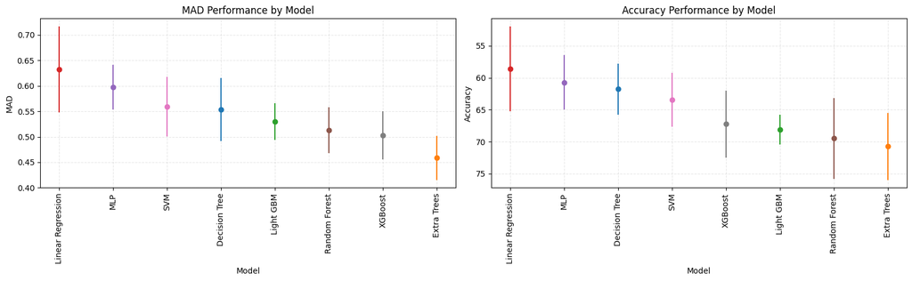

```python
# Filter the DataFrame for the 'mad' metric
mad_df = df_stats[df_stats['Metric'] == 'mad']
mad_df = mad_df.sort_values(by=['average'], ascending=False)
mad_df = mad_df.reset_index(drop=True)
# Create a subplot with 1 row and 2 columns
fig, axes = plt.subplots(nrows=1, ncols=2, figsize=(16, 5))
# Plot for 'mad' metric
axes[0].set_title("MAD Performance by Model")
for model, group in mad_df.groupby('Model'):
    axes[0].errorbar(x=group.index, y=group['average'], yerr=[group['average'] - group['lower'], group['upper'] - group['average']], fmt='o-', label=model)
axes[0].set_xlabel("Model")
axes[0].set_ylabel("MAD")
axes[0].set_xticks(mad_df.index)
axes[0].set_xticklabels(mad_df.Model, rotation=90)
axes[0].grid(True, alpha=0.3, linestyle='--')
# Filter the DataFrame for the 'accuracy' metric
accuracy_df = df_stats[df_stats['Metric'] == 'accuracy_within_tolerance']
accuracy_df = accuracy_df.sort_values(by=['average'], ascending=True)
accuracy_df = accuracy_df.reset_index(drop=True)
# Plot for 'accuracy' metric
axes[1].set_title("Accuracy Performance by Model")
for model, group in accuracy_df.groupby('Model'):
    axes[1].errorbar(x=group.index, y=group['average'], yerr=[group['average'] - group['lower'], group['upper'] - group['average']], fmt='o-', label=model)
axes[1].set_xlabel("Model")
axes[1].set_ylabel("Accuracy")
axes[1].set_xticks(accuracy_df.index)
axes[1].set_xticklabels(accuracy_df.Model, rotation=90)
axes[1].grid(True, alpha=0.3, linestyle='--')
axes[1].invert_yaxis()
# Adjust layout for better spacing
plt.tight_layout()
# Show the plot
plt.show()
```

We can see the performance of each Machine Learning technique. The graph plots the average MAD and Accuracy metrics with a 95% confidence interval from the *t-student* distribution.  
We can see that the highest (lowest) MAD (Accuracy) is produced by the Linear Regression model, followed by the Multilayer Perceptron model (MLP).  
Support Vector Machine (SVM) outperforms the Linear Regression and the MLP models by reaching a lower (higher) MAD (Accuracy). This reproduces the findings of Cortez (2009).  
In addition, we show the performance of ensemble trees and we note that these models consistently beat SVM. The Extra Trees model reach the lowest (highest) MAD (Accuracy), with XGBoost and Random Forest yielding similar performance.

Below we plot the Regression Error Characteristic (REC) Curve, which shows the accuracy by Machine Learning model for different tolerance thresholds.  
To simplify the comparison across models, we select XGBoost to represent the performance of ensemble trees.

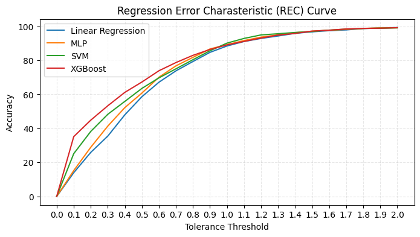

```python
# Regression Error Characteristic
tolerance_thresholds = np.arange(0, 2.1, 0.1)
rec_curve_lr = {model_name: [] for model_name in ['Linear Regression']}
rec_curve_mlp = {model_name: [] for model_name in ['MLP']}
rec_curve_svm = {model_name: [] for model_name in ['SVM']}
rec_curve_xgb = {model_name: [] for model_name in ['XGBoost']}
for threshold in tolerance_thresholds:
    scorers = {
    'mad': make_scorer(mean_absolute_error),
    'mse': make_scorer(mean_squared_error),
    'mape': make_scorer(calculate_mape),
    'smape': make_scorer(calculate_smape),
    'accuracy_within_tolerance': make_scorer(accuracy_within_tolerance, scaler_y=scaler_y, tolerance=threshold)
    }
    for model, model_name, rec_curve_dict in zip([lr_model, mlp_model, svm_model, xgb_model],
                                                ['Linear Regression', 'MLP', 'SVM', 'XGBoost'],
                                                [rec_curve_lr, rec_curve_mlp, rec_curve_svm, rec_curve_xgb]):
        cv_results = cross_validate(model, X, y, cv=kf, scoring=scorers)
        average_accuracy_at_threshold = np.mean(cv_results['test_accuracy_within_tolerance'])
        rec_curve_dict[model_name].append(average_accuracy_at_threshold)
# Plot REC curves
plt.figure(figsize=(8, 4))
for model_name, rec_curve_dict in zip(['Linear Regression', 'MLP', 'SVM', 'XGBoost'], [rec_curve_lr, rec_curve_mlp, rec_curve_svm, rec_curve_xgb]):
    rec_curve_array = np.array(list(rec_curve_dict[model_name]))
    plt.plot(tolerance_thresholds, rec_curve_array, label=f'{model_name}')

plt.xlabel('Tolerance Threshold')
plt.ylabel('Accuracy')
plt.title("Regression Error Charasteristic (REC) Curve")
plt.legend()
plt.grid(True,alpha=0.3,linestyle="--")
plt.xticks(tolerance_thresholds)
plt.show()
```

We can see that XGBoost generally outperforms SVM, MLP and Linear Regression, especially for lower thresholds, demonstrating its superior predictive capabilities.

Finally, we study feature importance for all Machine Learning models.  
We use Kernel and Tree explainers to compute SHAP values. Developed based on cooperative game theory, SHAP values provide a way to allocate contributions to each feature in a predictive model, indicating how much each feature contributes to the model's prediction.  
SHAP values aim to fairly distribute the contribution of each feature to the difference between a model's prediction for a specific instance and the average prediction. The process involves evaluating the impact of each feature by considering all possible combinations of features.  
Technically speaking, a SHAP value for a feature represents the average contribution of that feature to the output of the model across all possible combinations of features.  
Again, to simplify the comparison across models, we select XGBoost to represent the ensemble trees.

```python
# feature importance
lr_model = MLPRegressor(hidden_layer_sizes=(), max_iter=300, random_state=42)
mlp_model = MLPRegressor(hidden_layer_sizes=(100,), max_iter=300, random_state=42)
svm_model = SVR(kernel='rbf', C=3)
xgb_model = XGBRegressor(seed=42)
# Train the models
lr_model.fit(X_train, y_train)
mlp_model.fit(X_train, y_train)
svm_model.fit(X_train, y_train)
xgb_model.fit(X_train, y_train)
# Define SHAP explainer for each model using KernelExplainer
background_samples = shap.sample(X_train, 10)
explainer_lr = shap.KernelExplainer(lr_model.predict, background_samples, n_jobs=-1)
explainer_mlp = shap.KernelExplainer(mlp_model.predict, background_samples, n_jobs=-1)
explainer_svm = shap.KernelExplainer(svm_model.predict, background_samples, n_jobs=-1)
explainer_xgb = shap.TreeExplainer(xgb_model)
# Calculate SHAP values
shap_values_lr = explainer_lr.shap_values(X_train)
shap_values_mlp = explainer_mlp.shap_values(X_train)
shap_values_svm = explainer_svm.shap_values(X_train)
shap_values_xgb = explainer_xgb.shap_values(X_train)
# Aggregate SHAP values for each model
shap_values_lr_mean = np.abs(shap_values_lr).mean(axis=0)
shap_values_mlp_mean = np.abs(shap_values_mlp).mean(axis=0)
shap_values_svm_mean = np.abs(shap_values_svm).mean(axis=0)
shap_values_xgb_mean = np.abs(shap_values_xgb).mean(axis=0)
# Create pandas Series for each model
importance_lr = pd.Series(shap_values_lr_mean, index=df.loc[:, ~df.columns.isin(categorical)].columns).sort_values(ascending=False)
importance_mlp = pd.Series(shap_values_mlp_mean, index=df.loc[:, ~df.columns.isin(categorical)].columns).sort_values(ascending=False)
importance_svm = pd.Series(shap_values_svm_mean, index=df.loc[:, ~df.columns.isin(categorical)].columns).sort_values(ascending=False)
importance_xgb = pd.Series(shap_values_xgb_mean, index=df.loc[:, ~df.columns.isin(categorical)].columns).sort_values(ascending=False)
```

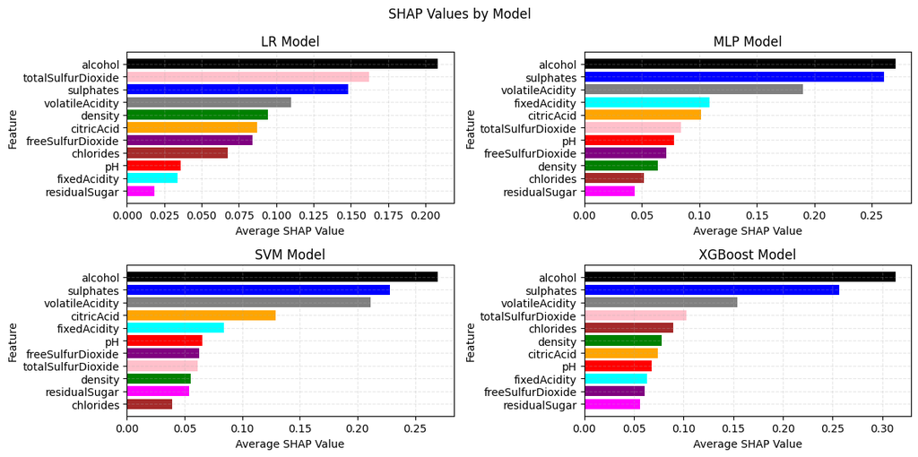

```python
# Define a list of named colors
named_colors = ['black', 'pink', 'blue', 'gray', 'green', 'orange', 'purple', 'brown', 'red', 'cyan', 'magenta']
# Create a color map with unique colors for each feature
color_map = {feature: named_colors[i % len(named_colors)] for i, feature in enumerate(importance_lr.index)}
# Plot feature importances in a 2x2 subplot
fig, axes = plt.subplots(nrows=2, ncols=2, figsize=(12, 6))
# LR
for i, feature in enumerate(importance_lr.index[0:20][::-1]):
    axes[0, 0].barh(feature, importance_lr[feature], color=color_map[feature])
axes[0, 0].set_title('LR Model')
axes[0, 0].set_ylabel('Feature')
axes[0, 0].set_xlabel('Average SHAP Value')
axes[0, 0].grid(True, alpha=0.3, linestyle="--")
# MLP
for i, feature in enumerate(importance_mlp.index[0:20][::-1]):
    axes[0, 1].barh(feature, importance_mlp[feature], color=color_map[feature])
axes[0, 1].set_title('MLP Model')
axes[0, 1].set_ylabel('Feature')
axes[0, 1].set_xlabel('Average SHAP Value')
axes[0, 1].grid(True, alpha=0.3, linestyle="--")
# SVM
for i, feature in enumerate(importance_svm.index[0:20][::-1]):
    axes[1, 0].barh(feature, importance_svm[feature], color=color_map[feature])
axes[1, 0].set_title('SVM Model')
axes[1, 0].set_ylabel('Feature')
axes[1, 0].set_xlabel('Average SHAP Value')
axes[1, 0].grid(True, alpha=0.3, linestyle="--")
# XGB
for i, feature in enumerate(importance_xgb.index[0:20][::-1]):
    axes[1, 1].barh(feature, importance_xgb[feature], color=color_map[feature])
axes[1, 1].set_title('XGBoost Model')
axes[1, 1].set_ylabel('Feature')
axes[1, 1].set_xlabel('Average SHAP Value')
axes[1, 1].grid(True, alpha=0.3, linestyle="--")
# Adjust layout
plt.suptitle("SHAP Values by Model")
plt.tight_layout()
plt.show()
```

We can see that feature importance is fairly homgeneous across all models, which is reassuring. For instance, `alcohol` is the feature with higher average SHAP Value across all models. This is followed by `sulphates` and `volatileAcidity` for most models. Only the Linear Regression model finds `totalSulfurDioxide` abnormally important, ranking the second most important feature.  
These results confirm the findings of the correlation analysis performed in the Descriptive Analysis.

In conclusion, we have demonstrated that while SVM outperforms Linear Regression and MLP in predicting red wine quality from physicochemical inputs, ensemble tree methods achieves even more promising results, outperforming SVM methods. This is important as it can help to improve wine production and it can be extended to other use cases in consumer preferences/tastes.